# Mixed Model

ChatGPT 4o

2025-01-21

## 1 起源

混合模型（Mixed Model），又称线性混合效应模型（Linear Mixed-Effects Model），是一种综合固定效应和随机效应的统计模型。它最早由Ronald Fisher在20世纪20年代提出的基础上演化而来。混合模型能够处理数据中的嵌套或分组结构，因此在农学、生物学、社会科学等领域有广泛应用，尤其适用于处理重复测量和具有复杂数据结构的场景。

## 2 原理

混合模型的核心原理是结合固定效应和随机效应来建模数据的整体结构：

- **固定效应（Fixed Effects）**：描述自变量对因变量的影响，这些影响适用于整个样本。例如，药物剂量对血压的影响。
- **随机效应（Random Effects）**：描述由样本中的不同群体（如个体、地点、时间）引起的变异。这些效应适用于样本的特定层次。例如，不同患者的个体差异。

混合模型可以表示为：

$$Y = X\beta + Z\gamma + \epsilon$$

其中，$Y$是响应变量，$X$是固定效应的设计矩阵，$\beta$是固定效应系数，$Z$是随机效应的设计矩阵，$\gamma$是随机效应系数，$\epsilon$是误差项。混合模型通过最大似然估计或限制最大似然估计来估计参数。

## 3 适用范围

混合模型适用于以下情况：

- **重复测量数据**：在实验中多次对同一对象进行测量，如不同时间点的测量数据。
- **嵌套数据**：当数据中存在嵌套结构（如学生嵌套在班级中，班级嵌套在学校中）时，混合模型适用于描述群体内和群体间的变异。
- **多级数据**：适用于具有多层次特征的数据，允许对不同层次的数据进行建模。

## 4 应用情境

混合模型在多个领域中都有广泛的应用，例如：

- **生物学和医学**：用于分析患者在治疗过程中的多次测量结果，研究个体间的差异对治疗效果的影响。
- **教育学**：研究学生在不同班级中的学业表现，评估班级和学校对个体成绩的影响。
- **心理学**：分析不同时间点对同一受试者的心理测量，评估心理状态的变化趋势。
- **农业和环境科学**：在农作物产量研究中，研究不同田块或地区对产量的影响。

## 5 优缺点

### 优点

- **处理复杂数据结构**：混合模型能够处理嵌套和重复测量数据，有效解决组内相关性问题。
- **灵活性强**：可以同时包含固定效应和随机效应，从而更灵活地描述数据结构中的变异。
- **适用于不平衡数据**：混合模型可以处理不平衡的数据，例如不同个体的观测次数不一致的情况。

### 缺点

- **模型复杂性高**：混合模型的构建和解释相对复杂，需要更高的统计知识和计算能力。
- **对模型假设敏感**：混合模型对数据的分布假设、线性关系假设等比较敏感，假设不成立可能会影响结果的可靠性。
- **计算开销大**：由于包含随机效应，参数估计涉及较高的计算复杂度，尤其是在大样本量或多层级结构的情况下。

## 6 在R中的实现及结果解释

在R中，可以使用`lme4`包中的`lmer()`函数来拟合混合模型。以下是一个实现混合模型的示例：

```r
# 加载必要的包
library(lme4)
```

```r
library(ggplot2)

# 示例数据：生成假设数据
set.seed(123)
data <- data.frame(
  subject_id = rep(1:50, each = 4),
  time = rep(1:4, times = 50),
  treatment = rep(c("A", "B"), each = 100),
  score = rnorm(200, mean = 75, sd = 10) + rep(rnorm(50, mean = 0, sd = 5), each = 4)
)

# 进行混合模型分析
mixed_model <- lmer(score ~ time + treatment + (1 | subject_id), data = data)

# 输出模型结果
summary(mixed_model)
```

```
## Linear mixed model fit by REML ['lmerMod']
## Formula: score ~ time + treatment + (1 | subject_id)
##    Data: data
##
## REML criterion at convergence: 1506.2
##
## Scaled residuals:
##      Min       1Q   Median       3Q      Max
## -2.62088 -0.63237 -0.00359  0.61936  2.92257
##
## Random effects:
##  Groups     Name        Variance Std.Dev.
##  subject_id (Intercept) 19.15    4.376
##  Residual               98.82    9.941
## Number of obs: 200, groups:  subject_id, 50
##
## Fixed effects:
##             Estimate Std. Error t value
## (Intercept) 76.56494    2.05545  37.250
## time        -0.04935    0.62873  -0.078
## treatmentB  -3.13971    1.87310  -1.676
##
## Correlation of Fixed Effects:
##            (Intr) time
## time       -0.765
## treatmentB -0.456  0.000
```

```r
str(mixed_model)
```

[output not shown]

[output cut: 77 more lines]

[output not shown]

### 结果的可视化

可以使用`ggplot2`包对混合模型的结果进行可视化，以展示个体间和总体的变化趋势。

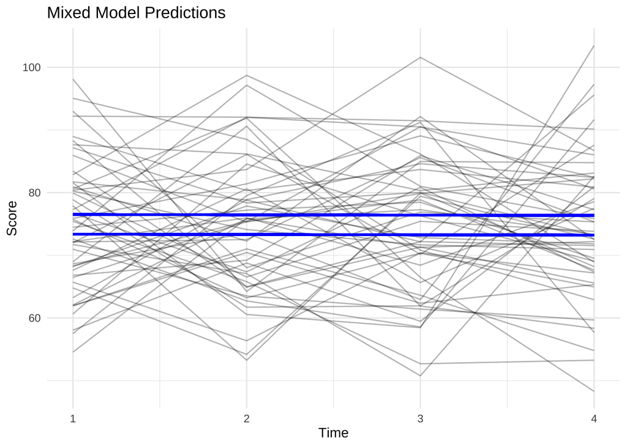

```r
# 预测混合模型的值
pred_data <- data
pred_data$predicted_score <- predict(mixed_model, newdata = pred_data, re.form = NA)

# 绘制个体的原始得分和预测得分
ggplot(pred_data, aes(x = time, y = score, group = subject_id)) +
  geom_line(alpha = 0.3) +
  geom_line(aes(y = predicted_score), color = "blue", size = 1) +
  labs(title = "Mixed Model Predictions", x = "Time", y = "Score") +
  theme_minimal()
```

上述代码将生成混合模型的拟合曲线，展示不同个体的原始得分和预测得分。灰色线条表示原始得分，蓝色线条表示模型预测的得分，用于直观地观察时间和治疗方式对得分的影响。

## 7 小结

- 混合模型是一种综合固定效应和随机效应的统计方法，能够有效地处理重复测量和嵌套数据。
- 适用于复杂数据结构，尤其是在存在组内相关性和多级数据的场景中。
- 具有处理复杂数据结构、灵活性强、适用于不平衡数据的优点，但对模型假设依赖较强，模型构建和解释较为复杂。
- 可以通过R中的`lmer()`函数实现混合模型分析，并结合可视化工具直观展示模型结果。
- 混合模型在生物学、教育学、心理学和农业等领域中有广泛的应用，是处理复杂数据的有力工具。